# Bio201 Final Project BRMPS

Yingyue Ding, Kevin Huang, Sunyimeng Lei, Clarissa Halim

11/18/2019

https://github.com/dyy980617/Bio201ThursPM/tree/master/Bio201ThursPM

Research Question: How does the consumption of a prebiotic affect the gut microbiomal community(diversity, changes in taxon abundance)?

In this Rmd we will be testing how consumption of BRMPS 2X daily will effect once gut microbiomal commnity in regard of richness and simpson diversity index, and beta divesity. Our hypothesis is there gonna be significant difference in these index. We did selcet quantity compliant.

# Load packages

```r
library(tidyverse)
library(readxl)
library(broom)
library(cowplot)
library(agricolae)
library(phyloseq); packageVersion("phyloseq")
library(vegan)
set.seed(7)
```

# Import data

### Sequence variants

```r
#convert txt to valid cvs, I have done this step, and upload "species_avg_shared.csv" to our reporsitory.

#species_avg_shared <- read_delim("C:/Users/tina5/OneDrive/Bio201ThursPM/raw_data/species_avg_shared.txt",
#                            delim = "\t", escape_double = FALSE,
#                            trim_ws = TRUE, na=c("NA"),
#                           col_types = list()) %>%   #import txt
# rename(participant_id_week = Participant_ID) %>%
#  select(-Semester)#don't need
#  species_avg_shared$participant_id_week = paste(species_avg_shared$participant_id_week,
#                                                 species_avg_shared$Study_week,
#                                                 sep="_") #create a combined name
#write.csv(species_avg_shared,file="C:/Users/tina5/OneDrive/Bio201ThursPM/curated_data/species_avg_shared.csv",quote=F,row.names = F)


species_avg_shared<-read_delim("~/Documents/Bio201ThursPM/curated_data/species_avg_shared.csv",
                            delim = ",", escape_double = FALSE,
                            trim_ws = TRUE, na=c("NA"),
                            col_types = list())
sv_table <- read_delim("~/Documents/Bio201ThursPM/curated_data/species_avg_shared.csv",
                            delim = ",", escape_double = FALSE,
                            trim_ws = TRUE, na=c("NA"),
                            col_types = list())  %>%
  mutate_if(is.numeric, round, digits = 0) %>%
  column_to_rownames(var = "participant_id_week") %>%
  as.matrix() %>%
  otu_table(., taxa_are_rows = FALSE)
```

### Taxa

Import taxonomy table and format for phyloseq.

```r
taxa <- read_delim("~/Documents/Bio201ThursPM/curated_data/seqvar_classifications.csv",
                            delim = ",", escape_double = FALSE,
                            trim_ws = TRUE, na=c("NA"),
                            col_types = list()) %>%
  column_to_rownames(var = "sv") %>%
  as.matrix() %>%
  tax_table(.)
```

### Participant data

Import sample data (where a sample is an individual microbiome sample) and format for phyloseq.

```r
all_data_wkly <- read_delim("~/Documents/Bio201ThursPM/raw_data/all_data_wkly.txt",
                            delim = "\t", escape_double = FALSE,
                            trim_ws = TRUE,
                            col_types = cols(Bristol_numeric = col_number(),
                                             Bristol_score = col_character(),
                                             pH = col_number())) %>%
  rename_all(tolower) %>%
  mutate(participant_id_week = participant_id)
all_data_wkly$participant_id_week = paste(all_data_wkly$participant_id,
                                                 all_data_wkly$study_week,
                                                 sep="_")

all_data_wkly_inner <- inner_join(x = all_data_wkly, y = species_avg_shared,
                                  by = c( "participant_id_week")) %>%
                      select( participant_id_week, study_week, semester, supplement_consumed,
                              quantity_compliant, frequency, ph_median, ph_mean, bristol_median,
                              bristol_mean, blood_glucose_median, blood_glucose_mean, acetate_median,
                              acetate_mean, butyrate_median ,butyrate_mean, propionate_median,
                              propionate_mean) %>%

                      distinct(., participant_id_week, .keep_all = TRUE) %>%
                      column_to_rownames(var = "participant_id_week") %>%
                      sample_data(.)
```

# Create phyloseq objects

```r
physq_obj <- phyloseq(sv_table, taxa, all_data_wkly_inner)

physq_obj
```

```
## phyloseq-class experiment-level object
## otu_table()   OTU Table:         [ 1160 taxa and 1202 samples ]
## sample_data() Sample Data:       [ 1202 samples by 17 sample variables ]
## tax_table()   Taxonomy Table:    [ 1160 taxa by 1 taxonomic ranks ]
```

# Richness

There are numerous alpha diversity metrics, however we are going to focus on number richness, and Simpson for our analyses. We will calculate, plot, extract information about alpha diversity with the plot_richness() funciton.

### Calculate richness

```r
richness_df <- physq_obj %>%
 subset_samples(supplement_consumed == "BRMPS")%>%
  subset_samples(frequency == "2xdaily") %>%
 subset_samples(quantity_compliant == "yes") %>%
subset_samples(study_week == "week1" | study_week == "week3") %>%
  estimate_richness(., split = TRUE,  measures = c("Observed")) %>%
  rownames_to_column(var = "participant_id_week") %>%
  inner_join(all_data_wkly, by = "participant_id_week")%>%
select(participant_id, study_week, Observed)%>%
  rename(richness = Observed)




write_delim(richness_df, path = "~/Documents/Bio201ThursPM/curated_data/richness_df.txt", delim = "\t")
```

### Plot richness

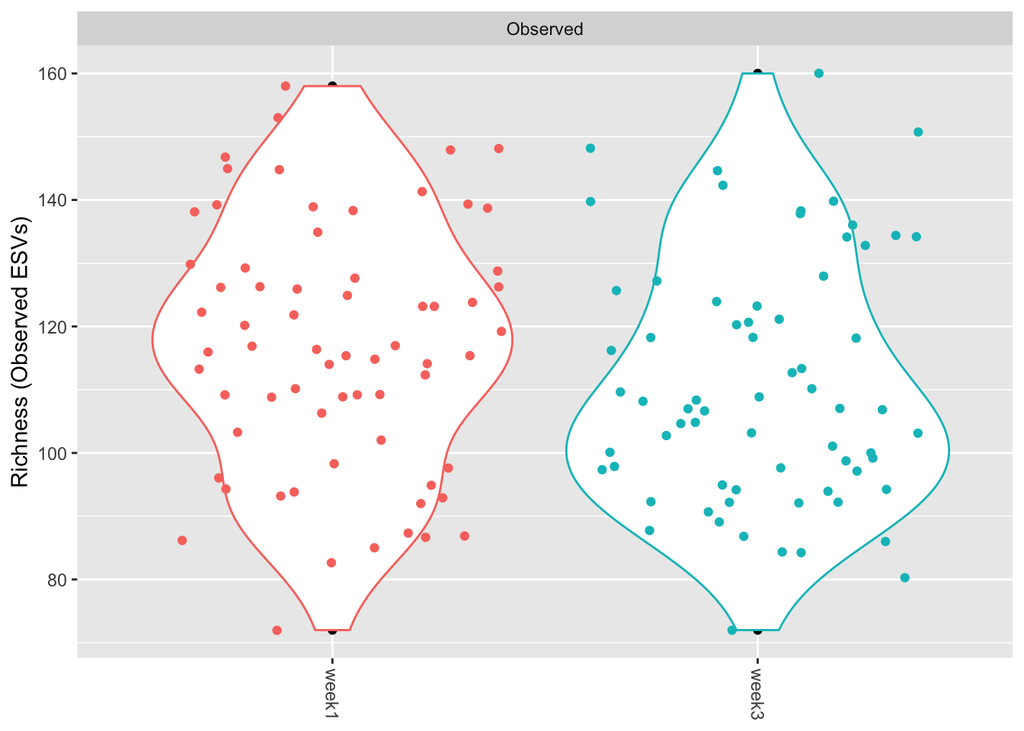

```r
rich1 <- physq_obj %>%
 subset_samples(supplement_consumed == "BRMPS")%>%
   subset_samples(frequency == "2xdaily") %>%
 subset_samples(quantity_compliant == "yes") %>%
subset_samples(study_week == "week1" | study_week == "week3") %>%
  plot_richness(., "study_week", measures = c("Observed")) +
  ylab("Richness (Observed ESVs)") + xlab(NULL)

rich2 <- rich1 +
  geom_violin(aes(color = study_week)) +
  geom_jitter(aes(color = study_week)) +
  theme(legend.position = "none")
rich2
```

```r
save_plot(filename = "~/Documents/Bio201ThursPM/figures/rich2.pdf",
          plot = rich2,
          nrow = 1, ncol = 2,
          base_aspect_ratio = 1.1)
```

```r
richness_df %>%
  group_by(study_week) %>%
summarise(sample_size = n())
```

```
## # A tibble: 2 x 2
##   study_week sample_size
##   <chr>            <int>
## 1 week1               67
## 2 week3               68
```

```r
richness_normal<-richness_df

  shapiro.test(richness_normal$richness)
```

```
##
##  Shapiro-Wilk normality test
##
## data:  richness_normal$richness
## W = 0.9813, p-value = 0.06064
```

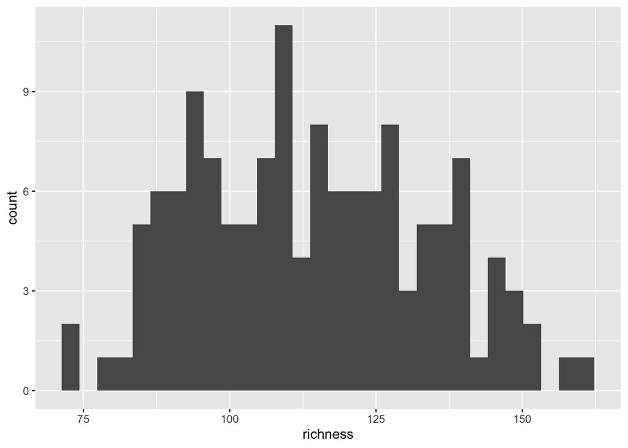

```r
ggplot(richness_normal, aes(x=richness)) +
  geom_histogram()
```

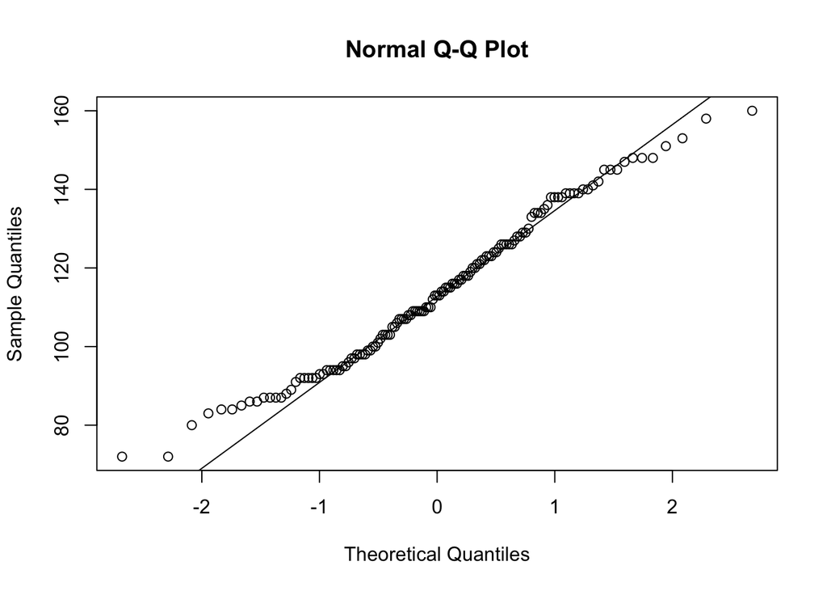

```r
qqnorm(richness_normal$richness); qqline(richness_normal$richness)
```

```r
richness_wk1<- richness_df%>%
  filter(study_week == "week1")
richness_wk3 <- richness_df %>%
  filter(study_week == "week3")
var.test(x = richness_wk1$richness,
         y = richness_wk3$richness,
         alternative = "two.sided")
```

```
##
##  F test to compare two variances
##
## data:  richness_wk1$richness and richness_wk3$richness
## F = 1.0097, num df = 66, denom df = 67, p-value = 0.9683
## alternative hypothesis: true ratio of variances is not equal to 1
## 95 percent confidence interval:
##  0.6220319 1.6403986
## sample estimates:
## ratio of variances
##           1.009687
```

```r
richness_df2 <- inner_join(x = richness_wk1, y = richness_wk3,
                    by = c("participant_id")) %>%
  rename(richness_wk1 = richness.x,
         richness_wk3 = richness.y)


t.test(x = richness_df2$richness_wk1,
       y = richness_df2$richness_wk3,
       alternative = "two.sided", paired = TRUE, var.equal = TRUE)
```

```
##
##  Paired t-test
##
## data:  richness_df2$richness_wk1 and richness_df2$richness_wk3
## t = 4.2427, df = 64, p-value = 7.263e-05
## alternative hypothesis: true difference in means is not equal to 0
## 95 percent confidence interval:
##   3.614424 10.047114
## sample estimates:
## mean of the differences
##                6.830769
```

p-value = 7.263e-05, significant difference in richness from wk1 to wk3, when consumption is BRMPS, 2x daily

# Simpson

To calculate Simpson diveristy index we repeat the process above for calcuating richness, the only thing we have to change is the `measures = c("Simpson")` argument for the plot_richness() and estimate_richness() functions.

### Calculate simpson

```r
simpson_df <- physq_obj %>%
 subset_samples(supplement_consumed == "BRMPS")%>%
   subset_samples(frequency == "2xdaily") %>%
 subset_samples(quantity_compliant == "yes") %>%
subset_samples(study_week == "week1" | study_week == "week3") %>%
  estimate_richness(., split = TRUE,  measures = c("Simpson")) %>%

rownames_to_column(var = "participant_id_week") %>% #reverse phyloseq object formatting
  inner_join(all_data_wkly, by = "participant_id_week")%>%
select(participant_id, study_week, Simpson)%>%
  rename(simpson = Simpson)


write_delim(simpson_df, path = "~/Documents/Bio201ThursPM/curated_data/simpson_df.txt", delim = "\t")
```

### Plot simpson

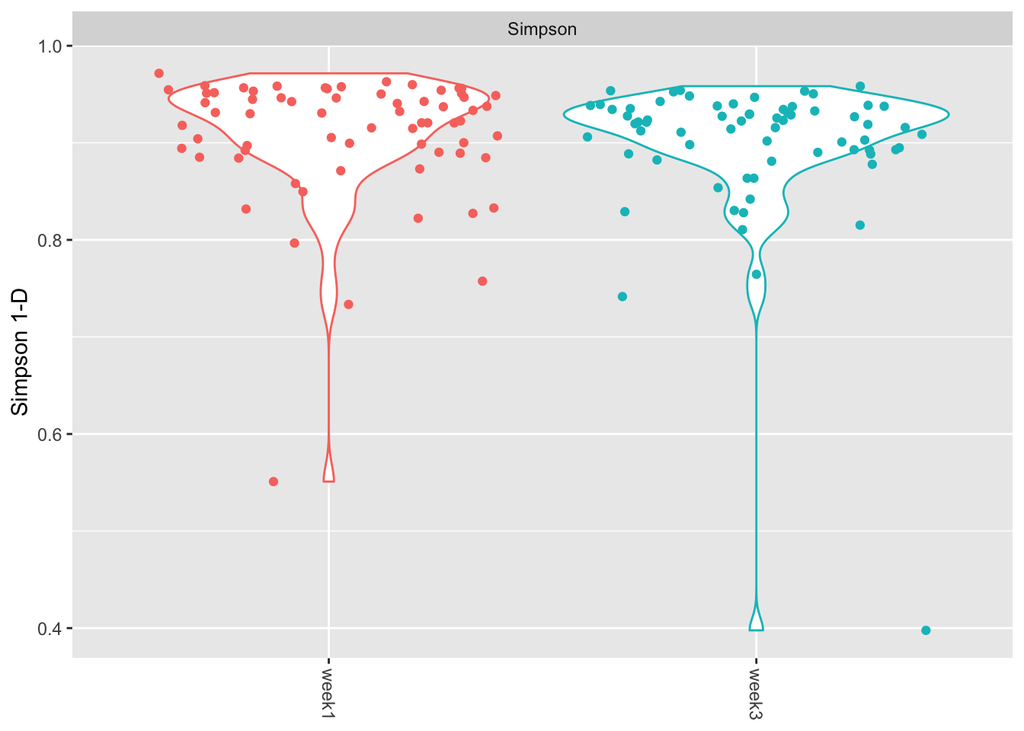

```r
simp1 <- physq_obj %>%
  subset_samples(supplement_consumed == "BRMPS")%>%
   subset_samples(frequency == "2xdaily") %>%
 subset_samples(quantity_compliant == "yes") %>%
subset_samples(study_week == "week1" | study_week == "week3") %>%
  plot_richness(., "study_week", measures = c("Simpson")) +
  ylab("Simpson 1-D") + xlab(NULL)
simp1$layers <- simp1$layers[-1]
simp2 <- simp1 +
  geom_violin(aes(color = study_week)) +
  geom_jitter(aes(color = study_week)) +
  theme(legend.position = "none")
simp2
```

```r
save_plot(filename = "~/Documents/Bio201ThursPM/figures/simp2.pdf",
          plot = rich2,
          nrow = 1, ncol = 2,
          base_aspect_ratio = 1.1)
```

```r
simpson_df %>%
  group_by(study_week) %>%
summarise(sample_size = n())
```

```
## # A tibble: 2 x 2
##   study_week sample_size
##   <chr>            <int>
## 1 week1               67
## 2 week3               68
```

```r
simpson_normal<-simpson_df

  shapiro.test(simpson_normal$simpson)
```

```
##
##  Shapiro-Wilk normality test
##
## data:  simpson_normal$simpson
## W = 0.64624, p-value < 2.2e-16
```

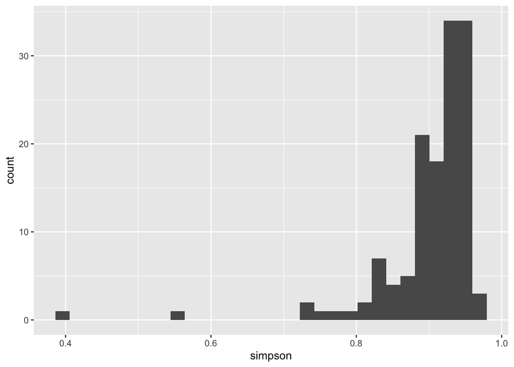

```r
ggplot(simpson_normal, aes(x=simpson)) +
  geom_histogram()
```

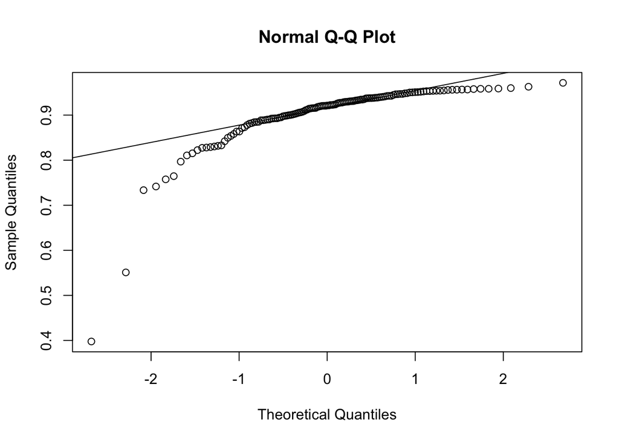

```r
qqnorm(simpson_normal$simpson); qqline(simpson_normal$simpson)
```

```r
simpson_wk1<- simpson_df%>%
  filter(study_week == "week1")
simpson_wk3 <- simpson_df %>%
  filter(study_week == "week3")
var.test(x = simpson_wk1$simpson,
         y = simpson_wk3$simpson,
         alternative = "two.sided")
```

```
##
##  F test to compare two variances
##
## data:  simpson_wk1$simpson and simpson_wk3$simpson
## F = 0.76452, num df = 66, denom df = 67, p-value = 0.2766
## alternative hypothesis: true ratio of variances is not equal to 1
## 95 percent confidence interval:
##  0.4709912 1.2420800
## sample estimates:
## ratio of variances
##           0.764517
```

```r
simpson_df2 <- inner_join(x = simpson_wk1, y = simpson_wk3,
                    by = c("participant_id")) %>%
  rename(simpson_wk1 = simpson.x,
         simpson_wk3 = simpson.y)


wilcox.test(x = simpson_df2$simpson_wk1,
       y = simpson_df2$simpson_wk3,
       alternative = "two.sided", paired = TRUE)
```

```
##
##  Wilcoxon signed rank test with continuity correction
##
## data:  simpson_df2$simpson_wk1 and simpson_df2$simpson_wk3
## V = 1507, p-value = 0.004566
## alternative hypothesis: true location shift is not equal to 0
```

p-value = 0.004566, significant difference in simpson from wk1 to wk3, when consumption is BRMPS, 2x daily

# Beta diveristy

### Conduct ordination analysis

This step calculates the diveristy index (using Bray Curtis in the example below), and does the ranking process of the diveristy indices to generate the information necessary to create a two-dimensional plot. Notice the arguments in the ordinate function; the index, Bray Curtis (“bray”) or Jaccard (“jaccard”), is specified in the distance agurment, and with either of these metrics we will use method = “NMDS”. The place were you might want to make some modifications is the k (this should be somewhere between 1-3), the maximum number of iterations (more than 100 will take several minutes to calcaulte), and the inital number of interations to try (50 in the example below). These can be modified to reduce the stress, with the goal of a number less than 0.20 (the lower the better).

```r
# Bray Curtis
physq_sub <- physq_obj %>%
  subset_samples(supplement_consumed == "BRMPS")%>%
   subset_samples(frequency == "2xdaily") %>%
 subset_samples(quantity_compliant == "yes") %>%
subset_samples(study_week == "week1" | study_week == "week3")
physq_sub
```

```
## phyloseq-class experiment-level object
## otu_table()   OTU Table:         [ 1160 taxa and 135 samples ]
## sample_data() Sample Data:       [ 135 samples by 17 sample variables ]
## tax_table()   Taxonomy Table:    [ 1160 taxa by 1 taxonomic ranks ]
```

```r
physq_bc <- ordinate(physq_sub,
                      method = "NMDS",
                      k=2, maxit=100, try=50,
                      distance = "bray")
```

```
## Square root transformation
## Wisconsin double standardization
## *** No convergence -- monoMDS stopping criteria:
##     22: no. of iterations >= maxit
##     28: stress ratio > sratmax
```

```r
physq_bc
```

```
##
## Call:
## metaMDS(comm = veganifyOTU(physeq), distance = distance, k = 2,      try = 50, maxit = 100)
##
## global Multidimensional Scaling using monoMDS
##
## Data:     wisconsin(sqrt(veganifyOTU(physeq)))
## Distance: bray
##
## Dimensions: 2
## Stress:     0.2150112
## Stress type 1, weak ties
## No convergent solutions - best solution after 50 tries
## Scaling: centring, PC rotation, halfchange scaling
## Species: expanded scores based on 'wisconsin(sqrt(veganifyOTU(physeq)))'
```

```r
# Jaccard
physq_j <- ordinate(physq_sub,
                      method = "NMDS",
                      k=2, maxit=100, try=50,
                      distance = "jaccard")
```

```
## Square root transformation
## Wisconsin double standardization
## *** Solution reached
```

```r
physq_j
```

```
##
## Call:
## metaMDS(comm = veganifyOTU(physeq), distance = distance, k = 2,      try = 50, maxit = 100)
##
## global Multidimensional Scaling using monoMDS
##
## Data:     wisconsin(sqrt(veganifyOTU(physeq)))
## Distance: jaccard
##
## Dimensions: 2
## Stress:     0.2150241
## Stress type 1, weak ties
## Two convergent solutions found after 50 tries
## Scaling: centring, PC rotation, halfchange scaling
## Species: expanded scores based on 'wisconsin(sqrt(veganifyOTU(physeq)))'
```

### Plot results and Modifications of ordination plots

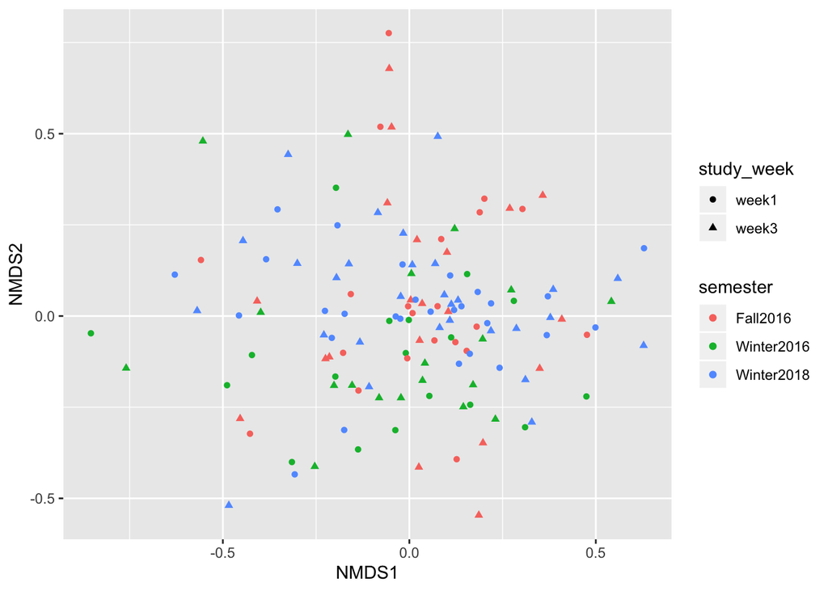

```r
# Bray Curtis
ordplot1 <- plot_ordination(physeq = physq_sub,
                     ordination = physq_bc,
                     type = "samples",
                     color = "semester",
                     shape = "study_week")
print(ordplot1)
```

```r
save_plot(filename = "~/Documents/Bio201ThursPM/figures/bc.pdf",
          plot = ordplot1,
          nrow = 1, ncol = 2,
          base_aspect_ratio = 1.1)
```

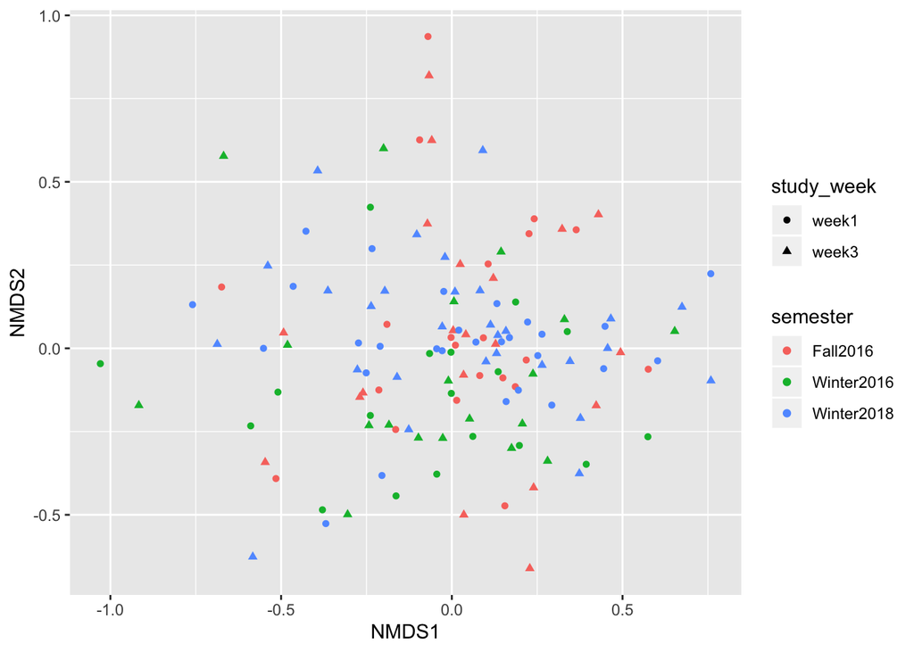

```r
# Jaccard
ordplot2 <- plot_ordination(physeq = physq_sub,
                     ordination = physq_j,
                     type = "samples",
                     color = "semester",
                     shape = "study_week")
print(ordplot2)
```

```r
save_plot(filename = "~/Documents/Bio201ThursPM/figures/ja.pdf",
          plot = ordplot2,
          nrow = 1, ncol = 2,
          base_aspect_ratio = 1.1)
```

### Statistical test

```r
# run Bray Curtis test
dat_bray <- phyloseq::distance(physq_sub, method = "bray")

sampledf <- physq_sub %>%
  sample_data(.) %>%
  as(., "data.frame")


adn_res <- adonis(formula = dat_bray ~  study_week * semester,
                  data = sampledf)
set.seed
```

[output not shown]

```r
print(adn_res)
```

```
##
## Call:
## adonis(formula = dat_bray ~ study_week * semester, data = sampledf)
##
## Permutation: free
## Number of permutations: 999
##
## Terms added sequentially (first to last)
##
##                      Df SumsOfSqs MeanSqs F.Model      R2 Pr(>F)
## study_week            1    0.3913 0.39130 1.85269 0.01354  0.015 *
## semester              2    1.1510 0.57548 2.72470 0.03982  0.001 ***
## study_week:semester   2    0.1172 0.05862 0.27752 0.00406  1.000
## Residuals           129   27.2459 0.21121         0.94259
## Total               134   28.9054                 1.00000
## ---
## Signif. codes:  0 '***' 0.001 '**' 0.01 '*' 0.05 '.' 0.1 ' ' 1
```

Conclusion for Bray-Curtis test

p-value for study week varies every time(for first run it is~0.015), R2 = 0.01354; significant difference in diversity from week 1 to week 3 for 2x consumers of BRMPS, but too low R2 value to determine that fiber supplement was the cause

```r
# run Jaccard test
dat_ja <- phyloseq::distance(physq_sub, method = "jaccard")

sampledf <- physq_sub %>%
  sample_data(.) %>%
  as(., "data.frame")


adn_2 <- adonis(formula = dat_ja ~  study_week,
                  data = sampledf)


print(adn_2)
```

```
##
## Call:
## adonis(formula = dat_ja ~ study_week, data = sampledf)
##
## Permutation: free
## Number of permutations: 999
##
## Terms added sequentially (first to last)
##
##             Df SumsOfSqs MeanSqs F.Model      R2 Pr(>F)
## study_week   1     0.431 0.43097  1.4054 0.01046   0.07 .
## Residuals  133    40.785 0.30665         0.98954
## Total      134    41.216                 1.00000
## ---
## Signif. codes:  0 '***' 0.001 '**' 0.01 '*' 0.05 '.' 0.1 ' ' 1
```

Conclusion for Jaccard test

p varies(for first run it is 0.07)，R2 = 0.01046; less significant difference in diversity from week 1 to week 3 for 2x consumers of BRMPS, but too low R2 value to determine that fiber supplement was the cause

end